# Merqury Rising Tutorial

Richard J. Edwards

07/11/2023

# 1 Introduction

This tutorial is designed to cover the basics of the main `MerquryRising.Rmd` markdown script. Following this initial commit, the two Rmd files will be edited in parallel to make the main Rmd more functional, and this Rmd have more information. Core functions have been moved to the `merquryrising.R` script, which can be run as a standalone Rscript to make the basic figures and tables without the extra fluff.

**NOTE:** This Tutorial is a work in progress. Please refer to the main Rmd file and post questions on GitHub in the meantime.

## 1.1 Contents of the Introduction

```r
# Genome assembly assessment criteria
# Kmers
# Kmer distributions (e.g. GenomeScope)
# Merqury plots and statistics

# MerquryRising

## Installation

## R libraries

# Input files for MerquryRising
# Setting ploidy boundaries
# Annotated Merqury Plot with the different features annotated and what they represent
# Categorisation of different kmer groups based on rfreq and afreq
# Translation into errors, under-purging, over-purging, good sequences and repeats

# For the main categories, inlcude a ## How does MerquryRising do this section

# Plots showing different elements in a Merqury plot [Might need the GenomeScope plot for the repeats?]
# Examples of good and bad assemblies
# Example of haploids and corresponding diploid
# Try the OG88 alt/pri and hap1/hap2 for this
# MerquryRising workflow [optional]
# MerquryRising class plot (which kind is most useful?)
# MerquryRising category plot
# MerquryRising difference plot
```

# 2 MerquryRising

MerquryRising is a standalone RMarkdown file for parsing outputs from [Merqury](https://github.com/marbl/merqury) and generating some additional plots to help assess the requirements and/or consequences of duplicate purging in genome assemblies. Please see the accompanying Tutorial.html for additional information about the rationale behind the program and its features. The GitHub README will also contain some information about running the script. If you are not getting the outputs you expect, please check or update the `merquryrising.config` configuration file, consisting of tab-delimited pairs of `setting` and `value`.

The Merqury files needed are:

- A set of `*.spectra-cn.hist` files of read and assembly kmer counts.
- A corresponding set of `*.only.hist` files of assembly-only kmer counts.
- An optional read kmer `*.hist.ploidy` file given with `ploidyfile=FILE`. If this is a `*.hist` file, this will be used to set all the boundaries.

Input files are read from the directory specified by `merqurydir=PATH` (default:`merqury`) and are set by `histfiles=X` (wildcards allowed, default:`*.spectra-cn.hist`). A matching set of `*.only.hist` files are also expected. Human-friendly labels can be provided with a `merquryrising.fofn` file (`labels=FILE`) that consists of `label filename` as plain text. `filename` in this instance is the full name of the `*.spectra-cn.hist` file, excluding the path, *e.g.*:

```
vhi2.0.hifiasm LutQuin_218497_OG10G.v230216hi2.0.hifiasm.merqury.LutQuin_218497_OG10G.v230216hi2.0.hifiasm.spectra-cn.hist
vhi2.1.pafscaff LutQuin_218497_OG10G.v230216hi2.1.pafscaff.merqury.LutQuin_218497_OG10G.v230216hi2.1.pafscaff.spectra-cn.hist
vhi2.2.diploidocus LutQuin_218497_OG10G.v230216hi2.2.diploidocus.merqury.LutQuin_218497_OG10G.v230216hi2.2.diploidocus.spectra-cn.hist
vhi2.3.ragtag LutQuin_218497_OG10G.v230216hi2.3.ragtag.merqury.LutQuin_218497_OG10G.v230216hi2.3.ragtag.spectra-cn.hist
vhi2.4.tweak LutQuin_218497_OG10G.v230216hi2.4.tweak.merqury.LutQuin_218497_OG10G.v230216hi2.4.tweak.spectra-cn.hist
vhi2.5.hypo LutQuin_218497_OG10G.v230216hi2.5.hypo.merqury.LutQuin_218497_OG10G.v230216hi2.5.hypo.spectra-cn.hist
vhi2.6.tidy2 LutQuin_218497_OG10G.v230216hi2.6.tidy2.merqury.LutQuin_218497_OG10G.v230216hi2.6.tidy2.spectra-cn.hist
```

1. Default mode will compare each kmer histogram with the preceding one.
2. Reference mode will compare every kmer histogram with the same reference. (Either named, else the first file.)

## 2.1 R libraries

`MerquryRising` makes use of the following libraries:

```
library(tidyverse)
library(ggridges)
library(grDevices)
library(GGally)
library(RColorBrewer)
library(writexl)
library(kableExtra)
library(tools)
library(patchwork)
```

## 2.2 Merqury Rising workflow

The general `MerquryRising` workflow is as follows:

- Run Merqury.
- Establish list of input assembly files and build alias list (`G1` to `Gn`).
- Load the read kmer frequency boundaries from the ploidy file: `ploidy`, `depth`, `boundary`.
- Load the `*.spectra-cn.hist` data tables into tibbles with 3 fields: `afreq` (kmer frequency in assembly), `rfreq` (kmer frequency in reads) and `knum` (number of different kmers).
- Convert the `read-only` kmers into `0` and make sure all fields are integers.
- Add the `*.only.hist` data to each table.
- Join all the count tables by `afreq` and `rfreq` to give a field per input file. (`G1` to `Gn`). [`Table1`]
- Convert `Table1` into a version of all values relative to reference. [`Table2`]
- Convert `Table1` into a long version [`Table3`] -> `knum` and `assembly`.
- Convert `Table3` `rfreq` into categories based on `ploidy`: `low`, `hap`, `dip`, `high`.
- Create a `Table3` `class` field, based on `afreq` and `rfreq` (see below)
- Collapse by `class` and sum up the `knum`
- Create a `Table4` from `Table3` with the `purge` categories (see below)
- Generate a horizontal stacked bar plot of each assembly: noise, only, lowQ, duplicate, alternate, haploid, diploid, repeats, collapsed, missing [`Table3`]
- Generate a horizontal stacked bar plot of each assembly: noise, only, under, good, over [`Table4`]
- Generate a kmer difference plot for each assembly versus the reference with afreq of 0, 1, 2, 3+ [`Table2`]
- Reshape `Table3` and `Table4` wide and convert into difference versus reference. Generate difference plots.

**NOTE:** The `only` class could indicate assembly errors, or it could indicate missing kmers due to sequencing biases. As such, they are excluded from the classification, as are the `noise` kmers, which are suspected read errors or contamination.

Please see the Tutorial for more details.

### 2.2.1 Kmer classes

Kmer classes will be assigned based on the read frequency (`rfreq`) and kmer frequency (`kfreq`), ploidy boundaries (see Tutorial and below), and whether the assembly is haploid or diploid. Classification is first based on more specific categories, which are then grouped into broader purge categories. The `dipclass` and `dippurge` ratings are used for diploid assemblies.

*Add table of class and purge descriptions.*

MerquryRising Kmer frequency classes.

| afreq | rfreq | class | purge | dipclass | dippurge |
| --- | --- | --- | --- | --- | --- |
| 1 | none | only | only | only | only |
| 2 | none | only | only | only | only |
| 3+ | none | only | only | only | only |
| 0 | low | noise | n/a | noise | n/a |
| 1 | low | lowQ | under | lowQ | under |
| 2 | low | lowQ | under | lowQ | under |
| 3+ | low | lowQ | under | lowQ | under |
| 0 | hap | alternate | good | alternate | good |
| 1 | hap | haploid | good | haploid | good |
| 2 | hap | duplicate | under | duplicate | under |
| 3+ | hap | duplicate | under | duplicate | under |
| 0 | dip | missing | over | missing | over |
| 1 | dip | diploid | good | haploid | over |
| 2 | dip | duplicate | under | diploid | good |
| 3+ | dip | duplicate | under | duplicate | under |
| 0 | high | missing | over | missing | over |
| 1 | high | collapsed | over | collapsed | over |
| 2 | high | collapsed | over | collapsed | over |
| 3+ | high | repeats | neutral | repeats | neutral |

# 3 Input Data

The main input for MerquryRising is the set of `*.spectra-cn.hist` and corresponding `.only.hist` files, with optional `qv/*.merqury.qv` and `stats/*.merqury.completeness.stats` files. The latter are matched on the `name` field, which is parsed from the `*.spectra-cn.hist` and split on `.merqury.`. (See the example data if unclear.)

Optionally, assembly names will be mapped from the `labels=FILE`, otherwise the label will be the “G” number, `G1` to `Gn`.

*Add the field descriptions here*.

## 3.1 Input files and assemblies

The following input files and assemblies have been recognised for this run:

Input genome assemblies and QV/completeness stats.

| G | label | name | hist | only | qv | completeness | base |
| --- | --- | --- | --- | --- | --- | --- | --- |
| G1 | vhi2.0.hifiasm | LutQuin_218497_OG10G.v230216hi2.0.hifiasm | TRUE | TRUE | 60.3855 | 86.3066 | LutQuin_218497_OG10G.v230216hi2.0.hifiasm.merqury.LutQuin_218497_OG10G.v230216hi2.0.hifiasm |
| G2 | vhi2.1.pafscaff | LutQuin_218497_OG10G.v230216hi2.1.pafscaff | TRUE | TRUE | 60.3855 | 86.3066 | LutQuin_218497_OG10G.v230216hi2.1.pafscaff.merqury.LutQuin_218497_OG10G.v230216hi2.1.pafscaff |
| G3 | vhi2.2.diploidocus | LutQuin_218497_OG10G.v230216hi2.2.diploidocus | TRUE | TRUE | 61.7651 | 86.1320 | LutQuin_218497_OG10G.v230216hi2.2.diploidocus.merqury.LutQuin_218497_OG10G.v230216hi2.2.diploidocus |
| G4 | vhi2.3.ragtag | LutQuin_218497_OG10G.v230216hi2.3.ragtag | TRUE | TRUE | 61.7651 | 86.1320 | LutQuin_218497_OG10G.v230216hi2.3.ragtag.merqury.LutQuin_218497_OG10G.v230216hi2.3.ragtag |
| G5 | vhi2.4.tweak | LutQuin_218497_OG10G.v230216hi2.4.tweak | TRUE | TRUE | 61.7651 | 86.1320 | LutQuin_218497_OG10G.v230216hi2.4.tweak.merqury.LutQuin_218497_OG10G.v230216hi2.4.tweak |
| G6 | vhi2.5.hypo | LutQuin_218497_OG10G.v230216hi2.5.hypo | TRUE | TRUE | 40.4451 | 86.1701 | LutQuin_218497_OG10G.v230216hi2.5.hypo.merqury.LutQuin_218497_OG10G.v230216hi2.5.hypo |
| G7 | vhi2.6.tidy2 | LutQuin_218497_OG10G.v230216hi2.6.tidy2 | TRUE | TRUE | 40.4444 | 86.1680 | LutQuin_218497_OG10G.v230216hi2.6.tidy2.merqury.LutQuin_218497_OG10G.v230216hi2.6.tidy2 |

## 3.2 Setting the ploidy boundaries

The next step is set the ploidy boundaries that establish `rfreq` categories as `low`, `haploid`, `diploid` or `high` frequencies. Assembly-only kmers are classified as `only`.

The original iterations of this script used the `boundary` values loaded from the `ploidy` file, but these appear to be quite conservative and result in a lot of kmers being rated as over- or under-purged based on the merqury plots themselves, with a lot of the main distributions broader than the values loaded. Ploidy boundaries are therefore set by default to be determined from the histograms themselves. For consistent boundaries, provide a `*.hist` file to the `ploidy=FILE` setting.

When `*.hist` files are used (assembly-specific or general), the diploid peak is first identified as the kmer density peak for rfreq values up to 1000. The boundaries are then calculated based on this `diploid` peak:

- `haploid` frequency is set to half `diploid`.
- The `low` boundary is set to the *maximum* value of 5, or 0.25 `haploid`. Upto this value of `rfreq` (raw read kmer frequency), kmers are rated `low`. This is plotted as a solid black line on the Comparative Merqury plots.
- The `mid` boundary is set to halfway between `haploid` and `diploid`. Raw kmer frequencies above the `low` boundary and upto the `mid` boundary `hap`. This is plotted as a solid red line on the Comparative Merqury plots, with the haploid peak a dotted red line.
- The `high` boundary is set to 1.5 `diploid`. Raw kmer frequencies above the `hap` boundary and upto the `high` boundary are rated `dip`. This is plotted as a solid blue line on the Comparative Merqury plots, with the diploid peak a dotted blue line.
- Above the `high` boundary, kmers are rated as `high`.

**NOTE:** For very heterozygous genomes, where the haploid peak exceeds the diploid peak, the diploid peak calculation will break. For these, it is advised to make and load a `*.ploidy` file to use for all assemblies.

**NOTE:** The classification percentages are ultimately defined by the ploidy boundaries, which do not fully capture the extent of each sub-distribution of kmers. As a consequence, there will always be a degree of mis-assigned kmers. For this reason, percentages are best considered as comparative values rather than absolute values.

## 3.3 Load and integrate kmer frequency data

## 3.4 Load hist tables

Generate `Table1` from the hist files.

```
## [Tue Nov  7 09:31:42 2023] #LOAD 41241 delim data rows loaded from merqury/LutQuin_218497_OG10G.v230216hi2.0.hifiasm.merqury.LutQuin_218497_OG10G.v230216hi2.0.hifiasm.spectra-cn.hist
## Calculating peak kmer frequency for ploidy...
## [Tue Nov  7 09:31:42 2023] Peak kmer frequency: 57.33
## [Tue Nov  7 09:31:42 2023] #LOAD 41241 delim data rows loaded from merqury/LutQuin_218497_OG10G.v230216hi2.1.pafscaff.merqury.LutQuin_218497_OG10G.v230216hi2.1.pafscaff.spectra-cn.hist
## Calculating peak kmer frequency for ploidy...
## [Tue Nov  7 09:31:42 2023] Peak kmer frequency: 57.33
## [Tue Nov  7 09:31:43 2023] #LOAD 43713 delim data rows loaded from merqury/LutQuin_218497_OG10G.v230216hi2.2.diploidocus.merqury.LutQuin_218497_OG10G.v230216hi2.2.diploidocus.spectra-cn.hist
## Calculating peak kmer frequency for ploidy...
## [Tue Nov  7 09:31:43 2023] Peak kmer frequency: 57.33
## [Tue Nov  7 09:31:43 2023] #LOAD 43713 delim data rows loaded from merqury/LutQuin_218497_OG10G.v230216hi2.3.ragtag.merqury.LutQuin_218497_OG10G.v230216hi2.3.ragtag.spectra-cn.hist
## Calculating peak kmer frequency for ploidy...
## [Tue Nov  7 09:31:43 2023] Peak kmer frequency: 57.33
## [Tue Nov  7 09:31:43 2023] #LOAD 43713 delim data rows loaded from merqury/LutQuin_218497_OG10G.v230216hi2.4.tweak.merqury.LutQuin_218497_OG10G.v230216hi2.4.tweak.spectra-cn.hist
## Calculating peak kmer frequency for ploidy...
## [Tue Nov  7 09:31:43 2023] Peak kmer frequency: 57.33
## [Tue Nov  7 09:31:43 2023] #LOAD 44265 delim data rows loaded from merqury/LutQuin_218497_OG10G.v230216hi2.5.hypo.merqury.LutQuin_218497_OG10G.v230216hi2.5.hypo.spectra-cn.hist
## Calculating peak kmer frequency for ploidy...
## [Tue Nov  7 09:31:44 2023] Peak kmer frequency: 57.33
## [Tue Nov  7 09:31:44 2023] #LOAD 44302 delim data rows loaded from merqury/LutQuin_218497_OG10G.v230216hi2.6.tidy2.merqury.LutQuin_218497_OG10G.v230216hi2.6.tidy2.spectra-cn.hist
## Calculating peak kmer frequency for ploidy...
## [Tue Nov  7 09:31:44 2023] Peak kmer frequency: 57.33
```

Ploidy boundaries.

| G | haploid | diploid | low | mid | high |
| --- | --- | --- | --- | --- | --- |
| G1 | 28.66608 | 57.33215 | 7.166519 | 42.99911 | 85.99823 |
| G2 | 28.66608 | 57.33215 | 7.166519 | 42.99911 | 85.99823 |
| G3 | 28.66607 | 57.33215 | 7.166518 | 42.99911 | 85.99822 |
| G4 | 28.66607 | 57.33215 | 7.166518 | 42.99911 | 85.99822 |
| G5 | 28.66607 | 57.33215 | 7.166518 | 42.99911 | 85.99822 |
| G6 | 28.66609 | 57.33218 | 7.166523 | 42.99914 | 85.99827 |
| G7 | 28.66609 | 57.33218 | 7.166523 | 42.99914 | 85.99827 |

# 4 Processing

## 4.1 Reference-normalised scores

Generate `Table2` from `Table1`, with all values relative to reference.

At this point, we have two “wide” tables of the kmer counts for each genome that belong to different assembly (`afreq`) and raw (`rfreq`) frequency classes. `Table1` has absolute values, whilst `Table2` has values relative to the reference.

## 4.2 Classification table

Generate `Table3`. This is a “long” version of Table 1, with the addition of a `knum` field. `afreq` and `rfreq` are then converted to the categories based on `afreq` and ploidy. Assembly-only kmers are arbitrarily given haploid or diploid kmer frequencies for the purposes of calculating the total kmer percentage for these categories.

`Table3` should now have haploid- and diploid-specific ratings.

# 5 Results

## 5.1 Purge classification

Purge rating (percentage).

| assembly | only | n/a | under | good | neutral | over | completeness | qv |
| --- | --- | --- | --- | --- | --- | --- | --- | --- |
| vhi2.0.hifiasm | 0.001 | 3.370 | 1.937 | 77.731 | 13.383 | 3.577 | 86.31 | 60.39 |
| vhi2.1.pafscaff | 0.001 | 3.370 | 1.937 | 77.731 | 13.383 | 3.577 | 86.31 | 60.39 |
| vhi2.2.diploidocus | 0.001 | 3.372 | 0.584 | 79.066 | 13.189 | 3.788 | 86.13 | 61.77 |
| vhi2.3.ragtag | 0.001 | 3.372 | 0.584 | 79.066 | 13.189 | 3.788 | 86.13 | 61.77 |
| vhi2.4.tweak | 0.001 | 3.372 | 0.584 | 79.066 | 13.189 | 3.788 | 86.13 | 61.77 |
| vhi2.5.hypo | 0.094 | 3.370 | 0.587 | 79.115 | 13.345 | 3.489 | 86.17 | 40.45 |
| vhi2.6.tidy2 | 0.094 | 3.370 | 0.582 | 79.120 | 13.343 | 3.491 | 86.17 | 40.44 |

```
## [Tue Nov  7 09:31:45 2023] #SAVE 7 Purge rating (percentage) table rows output to merquryrising.rating.tsv
```

```
## [Tue Nov  7 09:31:45 2023] #GGSAVE Saved output plot to plots/merquryrising.rating.pdf
```

```
## [Tue Nov  7 09:31:46 2023] #GGSAVE Saved output plot to plots/merquryrising.rating.png
```

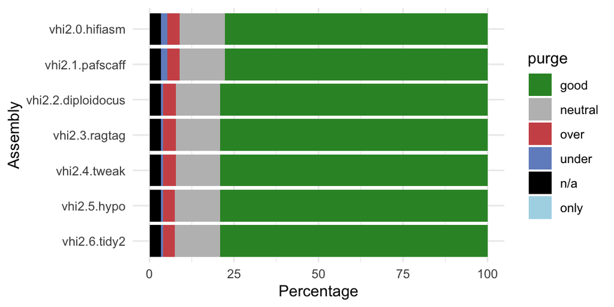

Kmer classification (percentage).

| assembly | only | noise | lowQ | duplicate | alternate | haploid | diploid | repeats | collapsed | missing |
| --- | --- | --- | --- | --- | --- | --- | --- | --- | --- | --- |
| vhi2.0.hifiasm | 0.001 | 3.370 | 0.008 | 1.930 | 6.319 | 9.748 | 61.664 | 13.383 | 3.193 | 0.384 |
| vhi2.1.pafscaff | 0.001 | 3.370 | 0.008 | 1.930 | 6.319 | 9.748 | 61.664 | 13.383 | 3.193 | 0.384 |
| vhi2.2.diploidocus | 0.001 | 3.372 | 0.006 | 0.578 | 6.389 | 9.796 | 62.881 | 13.189 | 3.358 | 0.431 |
| vhi2.3.ragtag | 0.001 | 3.372 | 0.006 | 0.578 | 6.389 | 9.796 | 62.881 | 13.189 | 3.358 | 0.431 |
| vhi2.4.tweak | 0.001 | 3.372 | 0.006 | 0.578 | 6.389 | 9.796 | 62.881 | 13.189 | 3.358 | 0.431 |
| vhi2.5.hypo | 0.094 | 3.370 | 0.005 | 0.582 | 5.915 | 10.253 | 62.947 | 13.345 | 3.211 | 0.278 |
| vhi2.6.tidy2 | 0.094 | 3.370 | 0.005 | 0.577 | 5.916 | 10.252 | 62.952 | 13.343 | 3.213 | 0.278 |

```
## [Tue Nov  7 09:31:47 2023] #SAVE 7 Kmer classification (percentage) table rows output to merquryrising.class.tsv
```

```
## [Tue Nov  7 09:31:47 2023] #GGSAVE Saved output plot to plots/merquryrising.class.pdf
```

```
## [Tue Nov  7 09:31:47 2023] #GGSAVE Saved output plot to plots/merquryrising.class.png
```

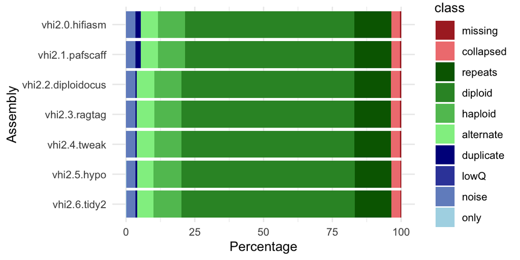

## 5.2 Relative purge classification

Relative purge rating (percentage).

| assembly | only | n/a | under | good | neutral | over | completeness | qv | G |
| --- | --- | --- | --- | --- | --- | --- | --- | --- | --- |
| vhi2.0.hifiasm | 0.000 | 0.000 | 0.000 | 0.000 | 0.000 | 0.000 | 0.00 | 0.00 | G1 |
| vhi2.1.pafscaff | 0.000 | 0.000 | 0.000 | 0.000 | 0.000 | 0.000 | 0.00 | 0.00 | G2 |
| vhi2.2.diploidocus | -0.000 | 0.002 | -1.353 | 1.334 | -0.193 | 0.211 | -0.17 | 1.38 | G3 |
| vhi2.3.ragtag | 0.000 | 0.000 | 0.000 | 0.000 | 0.000 | 0.000 | 0.00 | 0.00 | G4 |
| vhi2.4.tweak | 0.000 | 0.000 | 0.000 | 0.000 | 0.000 | 0.000 | 0.00 | 0.00 | G5 |
| vhi2.5.hypo | 0.093 | -0.002 | 0.004 | 0.049 | 0.155 | -0.299 | 0.04 | -21.32 | G6 |
| vhi2.6.tidy2 | -0.000 | 0.000 | -0.006 | 0.005 | -0.002 | 0.002 | -0.00 | -0.00 | G7 |

```
## [Tue Nov  7 09:31:48 2023] #GGSAVE Saved output plot to plots/merquryrising.relrating.pdf
```

```
## [Tue Nov  7 09:31:49 2023] #GGSAVE Saved output plot to plots/merquryrising.relrating.png
```

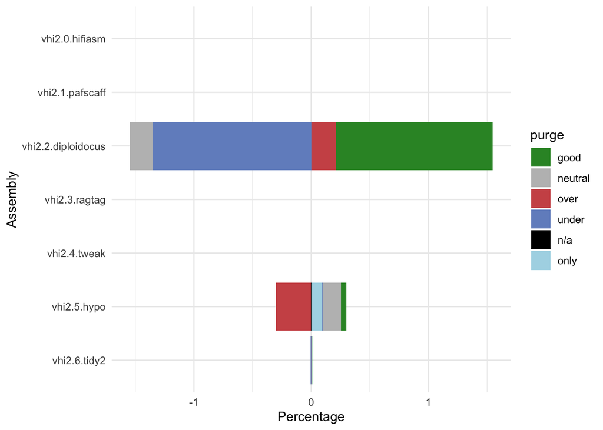

```
## [Tue Nov  7 09:31:49 2023] #GGSAVE Saved output plot to plots/merquryrising.relrating.pdf
```

```
## [Tue Nov  7 09:31:50 2023] #GGSAVE Saved output plot to plots/merquryrising.relrating.png
```

Relative Kmer classification (percentage).

| assembly | only | noise | lowQ | duplicate | alternate | haploid | diploid | repeats | collapsed | missing | G |
| --- | --- | --- | --- | --- | --- | --- | --- | --- | --- | --- | --- |
| vhi2.0.hifiasm | 0.000 | 0.000 | 0.000 | 0.000 | 0.000 | 0.000 | 0.000 | 0.000 | 0.000 | 0.000 | G1 |
| vhi2.1.pafscaff | 0.000 | 0.000 | 0.000 | 0.000 | 0.000 | 0.000 | 0.000 | 0.000 | 0.000 | 0.000 | G2 |
| vhi2.2.diploidocus | -0.000 | 0.002 | -0.002 | -1.352 | 0.070 | 0.047 | 1.217 | -0.193 | 0.165 | 0.046 | G3 |
| vhi2.3.ragtag | 0.000 | 0.000 | 0.000 | 0.000 | 0.000 | 0.000 | 0.000 | 0.000 | 0.000 | 0.000 | G4 |
| vhi2.4.tweak | 0.000 | 0.000 | 0.000 | 0.000 | 0.000 | 0.000 | 0.000 | 0.000 | 0.000 | 0.000 | G5 |
| vhi2.5.hypo | 0.093 | -0.002 | -0.001 | 0.005 | -0.474 | 0.457 | 0.066 | 0.155 | -0.147 | -0.153 | G6 |
| vhi2.6.tidy2 | -0.000 | 0.000 | -0.000 | -0.006 | 0.001 | -0.001 | 0.005 | -0.002 | 0.001 | 0.001 | G7 |

```
## [Tue Nov  7 09:31:50 2023] #GGSAVE Saved output plot to plots/merquryrising.relclass.pdf
```

```
## [Tue Nov  7 09:31:50 2023] #GGSAVE Saved output plot to plots/merquryrising.relclass.png
```

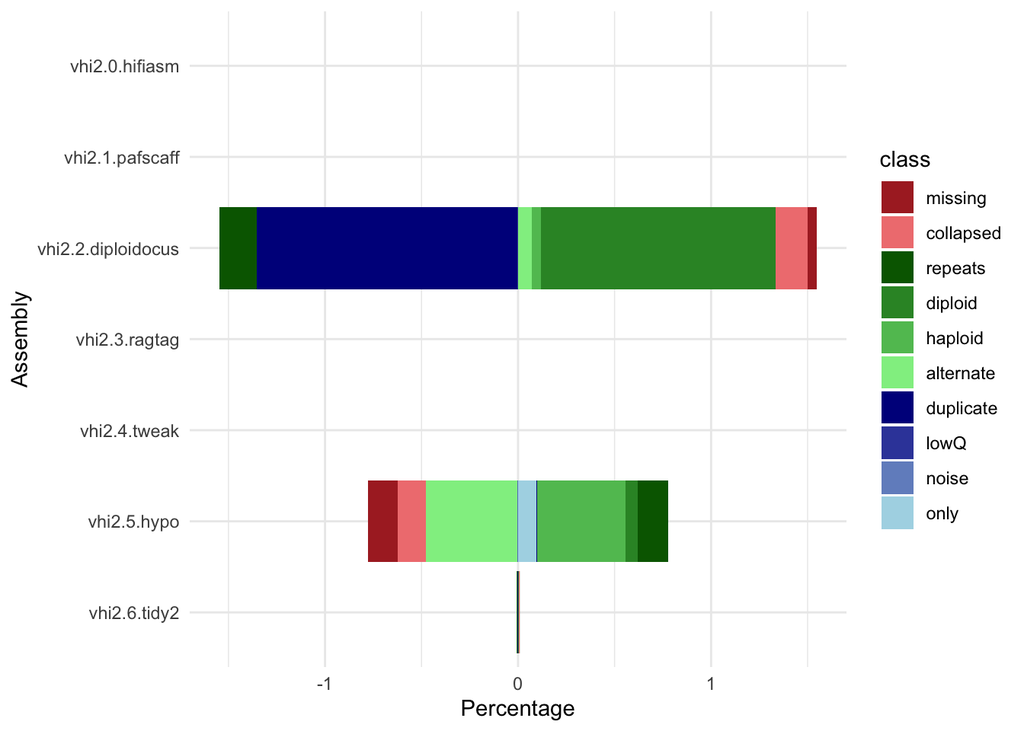

```
## [Tue Nov  7 09:31:51 2023] #GGSAVE Saved output plot to plots/merquryrising.relclass.pdf
```

```
## [Tue Nov  7 09:31:52 2023] #GGSAVE Saved output plot to plots/merquryrising.relclass.png
```

## 5.3 Comparative Merqury plots

These plots have been converted into relative values compared to the reference assembly. The reference assembly will have the full Merqury plot. Note that the read-only kmers (`afreq`=0) may be truncated.

### 5.3.1 vhi2.0.hifiasm

Merqury kmer statistics for LutQuin_218497_OG10G.v230216hi2.0.hifiasm (`LutQuin_218497_OG10G.v230216hi2.0.hifiasm.merqury.LutQuin_218497_OG10G.v230216hi2.0.hifiasm.*`). (No reference.)

Purge rating of vhi2.0.hifiasm

| assembly | only | n/a | under | good | neutral | over | completeness | qv |
| --- | --- | --- | --- | --- | --- | --- | --- | --- |
| vhi2.0.hifiasm | 0.001 | 3.370 | 1.937 | 77.731 | 13.383 | 3.577 | 86.31 | 60.39 |

kmer classes for vhi2.0.hifiasm

| assembly | only | noise | lowQ | duplicate | alternate | haploid | diploid | repeats | collapsed | missing |
| --- | --- | --- | --- | --- | --- | --- | --- | --- | --- | --- |
| vhi2.0.hifiasm | 0.001 | 3.370 | 0.008 | 1.930 | 6.319 | 9.748 | 61.664 | 13.383 | 3.193 | 0.384 |

Merqury plot for LutQuin_218497_OG10G.v230216hi2.0.hifiasm.

[Tue Nov 7 09:31:54 2023] #GGSAVE Saved output plot to plots/merquryrising.vhi2.0.hifiasm.pdf

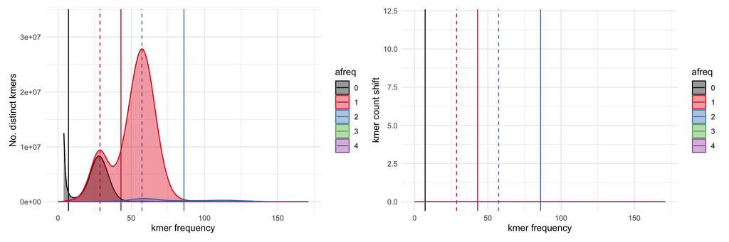

[Tue Nov 7 09:31:55 2023] #GGSAVE Saved output plot to plots/merquryrising.vhi2.0.hifiasm.png

### 5.3.2 vhi2.1.pafscaff

Merqury kmer statistics and relative purge stats for LutQuin_218497_OG10G.v230216hi2.1.pafscaff (`LutQuin_218497_OG10G.v230216hi2.1.pafscaff.merqury.LutQuin_218497_OG10G.v230216hi2.1.pafscaff.*`).

Relative purge rating of vhi2.1.pafscaff versus vhi2.0.hifiasm

| assembly | only | n/a | under | good | neutral | over | completeness | qv |
| --- | --- | --- | --- | --- | --- | --- | --- | --- |
| vhi2.0.hifiasm | 0.001 | 3.370 | 1.937 | 77.731 | 13.383 | 3.577 | 86.31 | 60.39 |
| change | 0.000 | 0.000 | 0.000 | 0.000 | 0.000 | 0.000 | 0.00 | 0.00 |
| vhi2.1.pafscaff | 0.001 | 3.370 | 1.937 | 77.731 | 13.383 | 3.577 | 86.31 | 60.39 |

Relative kmer classes of vhi2.1.pafscaff versus vhi2.0.hifiasm

| assembly | only | noise | lowQ | duplicate | alternate | haploid | diploid | repeats | collapsed | missing |
| --- | --- | --- | --- | --- | --- | --- | --- | --- | --- | --- |
| vhi2.0.hifiasm | 0.001 | 3.370 | 0.008 | 1.930 | 6.319 | 9.748 | 61.664 | 13.383 | 3.193 | 0.384 |
| change | 0.000 | 0.000 | 0.000 | 0.000 | 0.000 | 0.000 | 0.000 | 0.000 | 0.000 | 0.000 |
| vhi2.1.pafscaff | 0.001 | 3.370 | 0.008 | 1.930 | 6.319 | 9.748 | 61.664 | 13.383 | 3.193 | 0.384 |

Relative change of LutQuin_218497_OG10G.v230216hi2.1.pafscaff versus LutQuin_218497_OG10G.v230216hi2.0.hifiasm:

[Tue Nov 7 09:31:56 2023] #GGSAVE Saved output plot to plots/merquryrising.vhi2.1.pafscaff.pdf

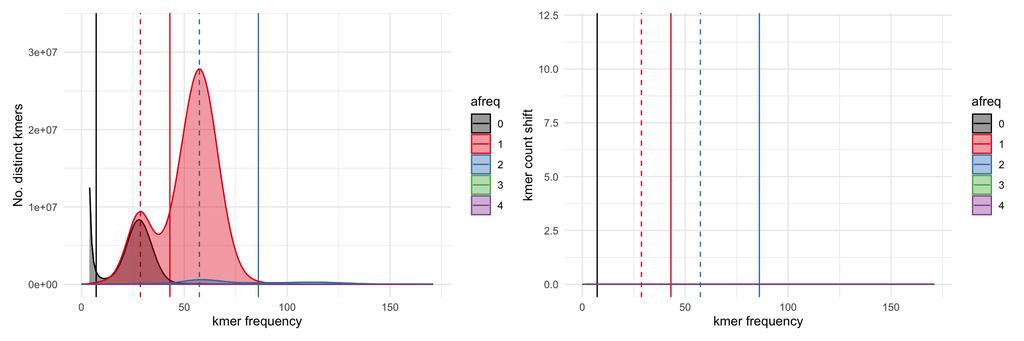

[Tue Nov 7 09:31:57 2023] #GGSAVE Saved output plot to plots/merquryrising.vhi2.1.pafscaff.png

### 5.3.3 vhi2.2.diploidocus

Merqury kmer statistics and relative purge stats for LutQuin_218497_OG10G.v230216hi2.2.diploidocus (`LutQuin_218497_OG10G.v230216hi2.2.diploidocus.merqury.LutQuin_218497_OG10G.v230216hi2.2.diploidocus.*`).

Relative purge rating of vhi2.2.diploidocus versus vhi2.1.pafscaff

| assembly | only | n/a | under | good | neutral | over | completeness | qv |
| --- | --- | --- | --- | --- | --- | --- | --- | --- |
| vhi2.1.pafscaff | 0.001 | 3.370 | 1.937 | 77.731 | 13.383 | 3.577 | 86.31 | 60.39 |
| change | -0.000 | 0.002 | -1.353 | 1.334 | -0.193 | 0.211 | -0.17 | 1.38 |
| vhi2.2.diploidocus | 0.001 | 3.372 | 0.584 | 79.066 | 13.189 | 3.788 | 86.13 | 61.77 |

Relative kmer classes of vhi2.2.diploidocus versus vhi2.1.pafscaff

| assembly | only | noise | lowQ | duplicate | alternate | haploid | diploid | repeats | collapsed | missing |
| --- | --- | --- | --- | --- | --- | --- | --- | --- | --- | --- |
| vhi2.1.pafscaff | 0.001 | 3.370 | 0.008 | 1.930 | 6.319 | 9.748 | 61.664 | 13.383 | 3.193 | 0.384 |
| change | -0.000 | 0.002 | -0.002 | -1.352 | 0.070 | 0.047 | 1.217 | -0.193 | 0.165 | 0.046 |
| vhi2.2.diploidocus | 0.001 | 3.372 | 0.006 | 0.578 | 6.389 | 9.796 | 62.881 | 13.189 | 3.358 | 0.431 |

Relative change of LutQuin_218497_OG10G.v230216hi2.2.diploidocus versus LutQuin_218497_OG10G.v230216hi2.1.pafscaff:

[Tue Nov 7 09:31:58 2023] #GGSAVE Saved output plot to plots/merquryrising.vhi2.2.diploidocus.pdf

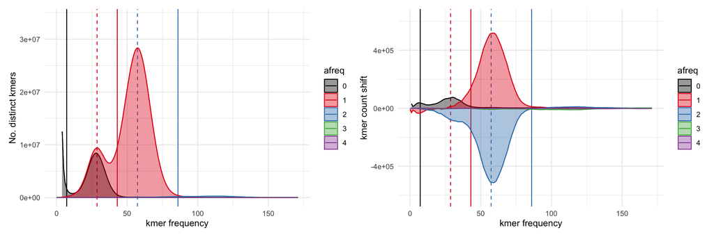

[Tue Nov 7 09:31:59 2023] #GGSAVE Saved output plot to plots/merquryrising.vhi2.2.diploidocus.png

### 5.3.4 vhi2.3.ragtag

Merqury kmer statistics and relative purge stats for LutQuin_218497_OG10G.v230216hi2.3.ragtag (`LutQuin_218497_OG10G.v230216hi2.3.ragtag.merqury.LutQuin_218497_OG10G.v230216hi2.3.ragtag.*`).

Relative purge rating of vhi2.3.ragtag versus vhi2.2.diploidocus

| assembly | only | n/a | under | good | neutral | over | completeness | qv |
| --- | --- | --- | --- | --- | --- | --- | --- | --- |
| vhi2.2.diploidocus | 0.001 | 3.372 | 0.584 | 79.066 | 13.189 | 3.788 | 86.13 | 61.77 |
| change | 0.000 | 0.000 | 0.000 | 0.000 | 0.000 | 0.000 | 0.00 | 0.00 |
| vhi2.3.ragtag | 0.001 | 3.372 | 0.584 | 79.066 | 13.189 | 3.788 | 86.13 | 61.77 |

Relative kmer classes of vhi2.3.ragtag versus vhi2.2.diploidocus

| assembly | only | noise | lowQ | duplicate | alternate | haploid | diploid | repeats | collapsed | missing |
| --- | --- | --- | --- | --- | --- | --- | --- | --- | --- | --- |
| vhi2.2.diploidocus | 0.001 | 3.372 | 0.006 | 0.578 | 6.389 | 9.796 | 62.881 | 13.189 | 3.358 | 0.431 |
| change | 0.000 | 0.000 | 0.000 | 0.000 | 0.000 | 0.000 | 0.000 | 0.000 | 0.000 | 0.000 |
| vhi2.3.ragtag | 0.001 | 3.372 | 0.006 | 0.578 | 6.389 | 9.796 | 62.881 | 13.189 | 3.358 | 0.431 |

Relative change of LutQuin_218497_OG10G.v230216hi2.3.ragtag versus LutQuin_218497_OG10G.v230216hi2.2.diploidocus:

[Tue Nov 7 09:32:00 2023] #GGSAVE Saved output plot to plots/merquryrising.vhi2.3.ragtag.pdf

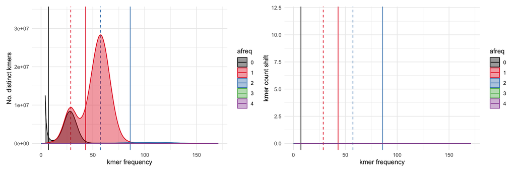

[Tue Nov 7 09:32:01 2023] #GGSAVE Saved output plot to plots/merquryrising.vhi2.3.ragtag.png

### 5.3.5 vhi2.4.tweak

Merqury kmer statistics and relative purge stats for LutQuin_218497_OG10G.v230216hi2.4.tweak (`LutQuin_218497_OG10G.v230216hi2.4.tweak.merqury.LutQuin_218497_OG10G.v230216hi2.4.tweak.*`).

Relative purge rating of vhi2.4.tweak versus vhi2.3.ragtag

| assembly | only | n/a | under | good | neutral | over | completeness | qv |
| --- | --- | --- | --- | --- | --- | --- | --- | --- |
| vhi2.3.ragtag | 0.001 | 3.372 | 0.584 | 79.066 | 13.189 | 3.788 | 86.13 | 61.77 |
| change | 0.000 | 0.000 | 0.000 | 0.000 | 0.000 | 0.000 | 0.00 | 0.00 |
| vhi2.4.tweak | 0.001 | 3.372 | 0.584 | 79.066 | 13.189 | 3.788 | 86.13 | 61.77 |

Relative kmer classes of vhi2.4.tweak versus vhi2.3.ragtag

| assembly | only | noise | lowQ | duplicate | alternate | haploid | diploid | repeats | collapsed | missing |
| --- | --- | --- | --- | --- | --- | --- | --- | --- | --- | --- |
| vhi2.3.ragtag | 0.001 | 3.372 | 0.006 | 0.578 | 6.389 | 9.796 | 62.881 | 13.189 | 3.358 | 0.431 |
| change | 0.000 | 0.000 | 0.000 | 0.000 | 0.000 | 0.000 | 0.000 | 0.000 | 0.000 | 0.000 |
| vhi2.4.tweak | 0.001 | 3.372 | 0.006 | 0.578 | 6.389 | 9.796 | 62.881 | 13.189 | 3.358 | 0.431 |

Relative change of LutQuin_218497_OG10G.v230216hi2.4.tweak versus LutQuin_218497_OG10G.v230216hi2.3.ragtag:

[Tue Nov 7 09:32:03 2023] #GGSAVE Saved output plot to plots/merquryrising.vhi2.4.tweak.pdf

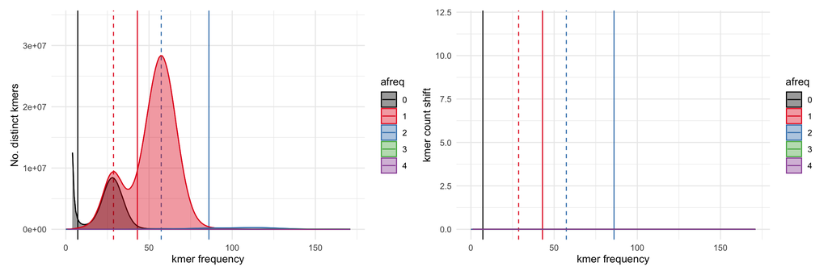

[Tue Nov 7 09:32:04 2023] #GGSAVE Saved output plot to plots/merquryrising.vhi2.4.tweak.png

### 5.3.6 vhi2.5.hypo

Merqury kmer statistics and relative purge stats for LutQuin_218497_OG10G.v230216hi2.5.hypo (`LutQuin_218497_OG10G.v230216hi2.5.hypo.merqury.LutQuin_218497_OG10G.v230216hi2.5.hypo.*`).

Relative purge rating of vhi2.5.hypo versus vhi2.4.tweak

| assembly | only | n/a | under | good | neutral | over | completeness | qv |
| --- | --- | --- | --- | --- | --- | --- | --- | --- |
| vhi2.4.tweak | 0.001 | 3.372 | 0.584 | 79.066 | 13.189 | 3.788 | 86.13 | 61.77 |
| change | 0.093 | -0.002 | 0.004 | 0.049 | 0.155 | -0.299 | 0.04 | -21.32 |
| vhi2.5.hypo | 0.094 | 3.370 | 0.587 | 79.115 | 13.345 | 3.489 | 86.17 | 40.45 |

Relative kmer classes of vhi2.5.hypo versus vhi2.4.tweak

| assembly | only | noise | lowQ | duplicate | alternate | haploid | diploid | repeats | collapsed | missing |
| --- | --- | --- | --- | --- | --- | --- | --- | --- | --- | --- |
| vhi2.4.tweak | 0.001 | 3.372 | 0.006 | 0.578 | 6.389 | 9.796 | 62.881 | 13.189 | 3.358 | 0.431 |
| change | 0.093 | -0.002 | -0.001 | 0.005 | -0.474 | 0.457 | 0.066 | 0.155 | -0.147 | -0.153 |
| vhi2.5.hypo | 0.094 | 3.370 | 0.005 | 0.582 | 5.915 | 10.253 | 62.947 | 13.345 | 3.211 | 0.278 |

Relative change of LutQuin_218497_OG10G.v230216hi2.5.hypo versus LutQuin_218497_OG10G.v230216hi2.4.tweak:

[Tue Nov 7 09:32:05 2023] #GGSAVE Saved output plot to plots/merquryrising.vhi2.5.hypo.pdf

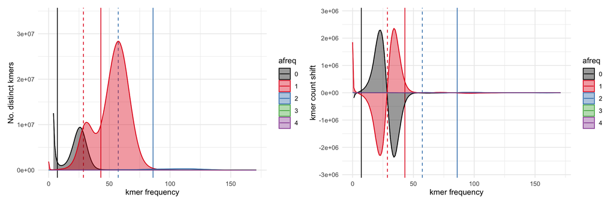

[Tue Nov 7 09:32:06 2023] #GGSAVE Saved output plot to plots/merquryrising.vhi2.5.hypo.png

### 5.3.7 vhi2.6.tidy2

Merqury kmer statistics and relative purge stats for LutQuin_218497_OG10G.v230216hi2.6.tidy2 (`LutQuin_218497_OG10G.v230216hi2.6.tidy2.merqury.LutQuin_218497_OG10G.v230216hi2.6.tidy2.*`).

Relative purge rating of vhi2.6.tidy2 versus vhi2.5.hypo

| assembly | only | n/a | under | good | neutral | over | completeness | qv |
| --- | --- | --- | --- | --- | --- | --- | --- | --- |
| vhi2.5.hypo | 0.094 | 3.370 | 0.587 | 79.115 | 13.345 | 3.489 | 86.17 | 40.45 |
| change | -0.000 | 0.000 | -0.006 | 0.005 | -0.002 | 0.002 | -0.00 | -0.00 |
| vhi2.6.tidy2 | 0.094 | 3.370 | 0.582 | 79.120 | 13.343 | 3.491 | 86.17 | 40.44 |

Relative kmer classes of vhi2.6.tidy2 versus vhi2.5.hypo

| assembly | only | noise | lowQ | duplicate | alternate | haploid | diploid | repeats | collapsed | missing |
| --- | --- | --- | --- | --- | --- | --- | --- | --- | --- | --- |
| vhi2.5.hypo | 0.094 | 3.370 | 0.005 | 0.582 | 5.915 | 10.253 | 62.947 | 13.345 | 3.211 | 0.278 |
| change | -0.000 | 0.000 | -0.000 | -0.006 | 0.001 | -0.001 | 0.005 | -0.002 | 0.001 | 0.001 |
| vhi2.6.tidy2 | 0.094 | 3.370 | 0.005 | 0.577 | 5.916 | 10.252 | 62.952 | 13.343 | 3.213 | 0.278 |

Relative change of LutQuin_218497_OG10G.v230216hi2.6.tidy2 versus LutQuin_218497_OG10G.v230216hi2.5.hypo:

[Tue Nov 7 09:32:08 2023] #GGSAVE Saved output plot to plots/merquryrising.vhi2.6.tidy2.pdf

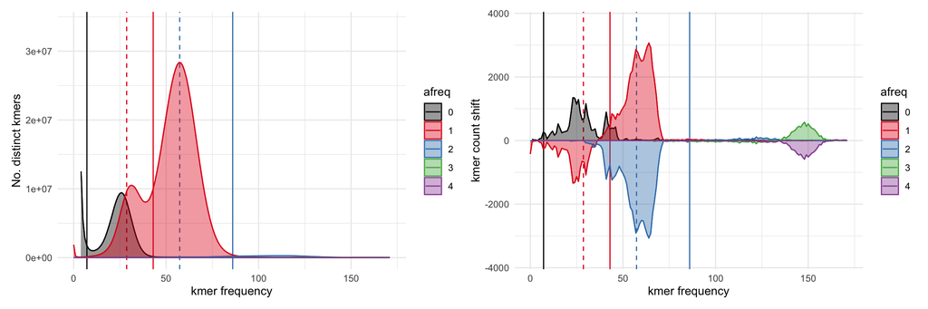

[Tue Nov 7 09:32:09 2023] #GGSAVE Saved output plot to plots/merquryrising.vhi2.6.tidy2.png